# Midterm Project: Value of Promotion and Advertisement for General Mills

David Deans

May 06, 2019

```r
# The tidyverse package contains ggplot2, tibble, tidyr, readr, purr, and dplyr and several others
library(tidyverse)
#The gridExtra package contains grid.arrange function used to combine plots
library(gridExtra)
#The janitor package contains tabyl, a tidyverse friendly multi-variate non-graphical function
library(janitor)
#The stringr package contains str_replace, str_detect, etc as well as join options
library(stringr)
#ggrepel package helps keep data-labels out of the way of the graph
library(ggrepel)
#Devtools is a ggthemr dependency
library(devtools)
#Use devtools to install ggthemr
devtools::install_github('cttobin/ggthemr')
#ggthemr package contains many premade themes for ggplot2
library(ggthemr)
```

```r
#Set theme to dust using ggthemr
ggthemr('dust')
```

# 1 Data Review

```r
# Load data
sd <- read.csv("mtp_sales_data.csv")
pd <- read.csv("mtp_product_data.csv")
#Look at the head of both datasets
head(sd)
```

```
##              UPC iri_key week units price promo   ad
## 1 01.16000.11653  644347    6     5   0.5     0    A
## 2 01.16000.11653  248741    5     2   0.5     0 NONE
## 3 01.16000.11653  535806   11     3   0.5     0 NONE
## 4 01.16000.11945  675634   11     2   0.5     0 NONE
## 5 01.16000.11945  205272   13     8   0.5     0 NONE
## 6 01.16000.11945  248741   14     5   0.5     0 NONE
```

```r
head(pd)
```

```
##                 UPC                         brand         flavor volume
## 1 00-01-16000-11653 GENERAL MILLS CINNAMON TST CR CINNAMON TOAST   0.06
## 2 00-01-16000-11945        GENERAL MILLS CHEERIOS        TOASTED   0.04
## 3 00-01-16000-14154 GENERAL MILLS CINNAMON TST CR CINNAMON TOAST   0.12
## 4 00-01-16000-14156    GENERAL MILLS LUCKY CHARMS        TOASTED   0.11
## 5 00-01-16000-14159        GENERAL MILLS CHEERIOS        TOASTED   0.08
## 6 00-01-16000-16179     GENERAL MILLS COCOA PUFFS          COCOA   0.89
##   package
## 1     BOX
## 2     BOX
## 3     CUP
## 4     CUP
## 5     CUP
## 6     BOX
```

```r
#Transform data to better fit our purposes
sd$iri_key <- as.factor(sd$iri_key) #Store numbers should be factors
sd$week <- as.factor(sd$week) #Week should be factor as well
sd$promo <- as.factor(sd$promo) #promotion should be factor as well
x <- pd$UPC #store UPC
```

```r
#Makes the UPC layout match for each data set.
pd$UPC <- x #Draws from stored UPC value

pd$UPC <- pd$UPC %>%
  str_replace_all("-",".") %>% #Replaces - with . to fit sd's style
  str_sub(4,17) #Removes the first 3 characters so that the style is 01. rather than 00.01.
pd$UPC <- as.factor(pd$UPC) #Turn product UPC into a factor to match sales UPC

#Join Datasets
fd <- full_join(sd,pd,by = "UPC", copy = FALSE)#Full join on UPC to get all columns from both tables
#View Data
head(fd) #Saved as fd as in "full data"
```

```
##              UPC iri_key week units price promo   ad
## 1 01.16000.11653  644347    6     5   0.5     0    A
## 2 01.16000.11653  248741    5     2   0.5     0 NONE
## 3 01.16000.11653  535806   11     3   0.5     0 NONE
## 4 01.16000.11945  675634   11     2   0.5     0 NONE
## 5 01.16000.11945  205272   13     8   0.5     0 NONE
## 6 01.16000.11945  248741   14     5   0.5     0 NONE
##                           brand         flavor volume package
## 1 GENERAL MILLS CINNAMON TST CR CINNAMON TOAST   0.06     BOX
## 2 GENERAL MILLS CINNAMON TST CR CINNAMON TOAST   0.06     BOX
## 3 GENERAL MILLS CINNAMON TST CR CINNAMON TOAST   0.06     BOX
## 4        GENERAL MILLS CHEERIOS        TOASTED   0.04     BOX
## 5        GENERAL MILLS CHEERIOS        TOASTED   0.04     BOX
## 6        GENERAL MILLS CHEERIOS        TOASTED   0.04     BOX
```

```r
#Create new column company, will be equal to brand for now
fd$company <- fd$brand
```

```r
#fd2 is the new dataset we will be working with
fd2 <- fd %>%
  #remove company name from brand
  mutate(brand = str_remove_all(fd$brand, "GENERAL MILLS |KELLOGGS |POST ")) %>%
  #remove cereal type from company
  mutate(company = str_remove_all(fd$company, " CINNAMON TST CR| GRAPE NUTS| CHEERIOS| LUCKY CHARMS| RAISIN BRAN| COCOA PUFFS| KIX| SPECIAL K| FROOT LOOPS| SMART START| FROSTED MINI WHEATS| RICE KRISPIES| FROSTED FLAKES| COCOA KRISPIES| SHREDDED WHEAT"))

#Get rid of any remaining whitespace in brand and company
fd2$brand <- str_squish(fd2$brand)
fd2$company <- str_squish(fd2$company)


#convert into factor
fd2$company <- as.factor(fd2$company)
fd2$brand <- as.factor(fd2$brand)
```

# 2 Univariate non-graphical EDA

```r
#Inspect descriptive statistics of data
head(fd2)
```

```
##              UPC iri_key week units price promo   ad           brand
## 1 01.16000.11653  644347    6     5   0.5     0    A CINNAMON TST CR
## 2 01.16000.11653  248741    5     2   0.5     0 NONE CINNAMON TST CR
## 3 01.16000.11653  535806   11     3   0.5     0 NONE CINNAMON TST CR
## 4 01.16000.11945  675634   11     2   0.5     0 NONE        CHEERIOS
## 5 01.16000.11945  205272   13     8   0.5     0 NONE        CHEERIOS
## 6 01.16000.11945  248741   14     5   0.5     0 NONE        CHEERIOS
##           flavor volume package       company
## 1 CINNAMON TOAST   0.06     BOX GENERAL MILLS
## 2 CINNAMON TOAST   0.06     BOX GENERAL MILLS
## 3 CINNAMON TOAST   0.06     BOX GENERAL MILLS
## 4        TOASTED   0.04     BOX GENERAL MILLS
## 5        TOASTED   0.04     BOX GENERAL MILLS
## 6        TOASTED   0.04     BOX GENERAL MILLS
```

```r
summary(fd2)
```

```
##              UPC           iri_key           week           units
##  01.43000.10521:  676   656444 :   35   22     :  475   Min.   : 1.000
##  01.38000.01621:  666   256951 :   31   12     :  473   1st Qu.: 3.000
##  01.38000.00828:  660   259661 :   31   37     :  464   Median : 7.000
##  01.16000.27569:  639   267403 :   31   29     :  449   Mean   : 8.579
##  02.38000.66330:  618   652139 :   31   20     :  445   3rd Qu.:12.000
##  01.38000.01611:  612   681735 :   31   43     :  445   Max.   :28.000
##  (Other)       :17979   (Other):21660   (Other):19099
##      price       promo        ad                        brand
##  Min.   :0.250   0:17305   A   : 1456   FROSTED FLAKES     : 2295
##  1st Qu.:3.190   1: 4545   B   : 1061   FROOT LOOPS        : 2192
##  Median :3.790             NONE:19333   CINNAMON TST CR    : 1834
##  Mean   :3.763                          LUCKY CHARMS       : 1681
##  3rd Qu.:4.390                          FROSTED MINI WHEATS: 1574
##  Max.   :9.990                          CHEERIOS           : 1458
##                                         (Other)            :10816
##             flavor         volume      package              company
##  CINNAMON TOAST:1834   Min.   :0.040   BOX:21306   GENERAL MILLS: 7189
##  COCOA         :1901   1st Qu.:0.750   CUP:  544   KELLOGGS     :12183
##  FRUIT         :2192   Median :1.060               POST         : 2478
##  REGULAR       :8816   Mean   :1.016
##  TOASTED       :7107   3rd Qu.:1.120
##                        Max.   :4.000
##
```

## 2.1 Comments

- Main Goal: Find significant findings related to the effectiveness of advertising promotions
- Price listed is what is paid at checkout
- Promotions mean the item is discounted at least 5 percent
- Does brand or promotion have a larger impact on flavor purchasing?
- Which brands are more popular to promotions?
  - Which brands sell regardless of promotions, which struggle to sell unless there is one?
  - Is there any brand unaffected by promotion?
- What are the impact of ads?
  - Which brands benefit the most from big/small ads and promos?

# 3 Univariate graphical EDA

## 3.1 Bar Graphs

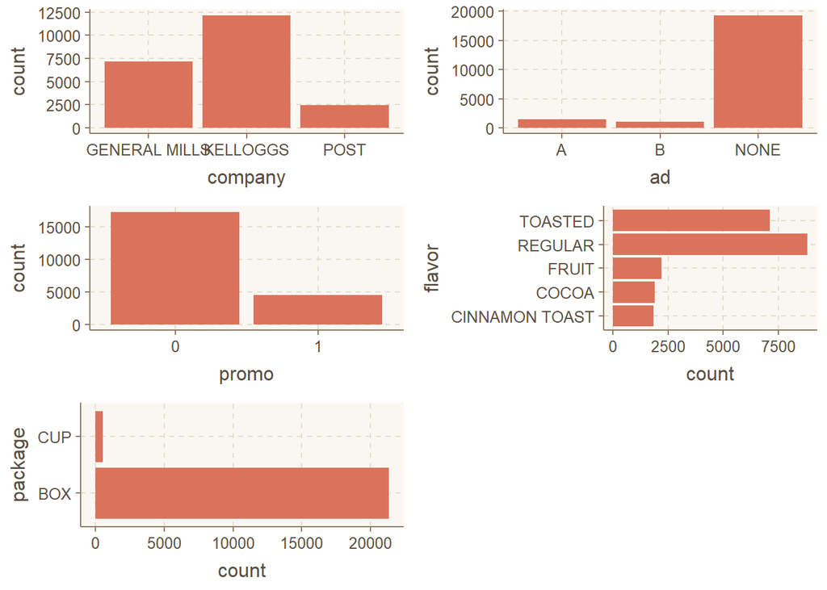

```r
# Using univariate bar graphs with grid.arrange (gridExtra package) to see all quantitative variables together. "x=" is not used because aes() expects x first.
  grid.arrange(
    fd2 %>%
      ggplot(aes(company)) +
        geom_bar(),
    fd2 %>%
      ggplot(aes(ad)) +
        geom_bar(),
    fd2 %>%
      ggplot(aes(promo)) +
        geom_bar(),
    fd2 %>%
      ggplot(aes(flavor)) +
        geom_bar() +
        coord_flip(),
    fd2 %>%
      ggplot(aes(package)) +
        geom_bar() +
        coord_flip(),
    ncol = 2

  )
```

### 3.1.1 Comments

- Kelloggs has the highest count, but we will need to see the units and price sold at
- Could be possible many more people buy Kelloggs but it sells for cheaper than General Mills
- Is Post so small because people buy in bulk?
- A is picked more than B for advertisement, is that the smart call for General Mills?
- How do promos impact our sales?

## 3.2 Box Plots

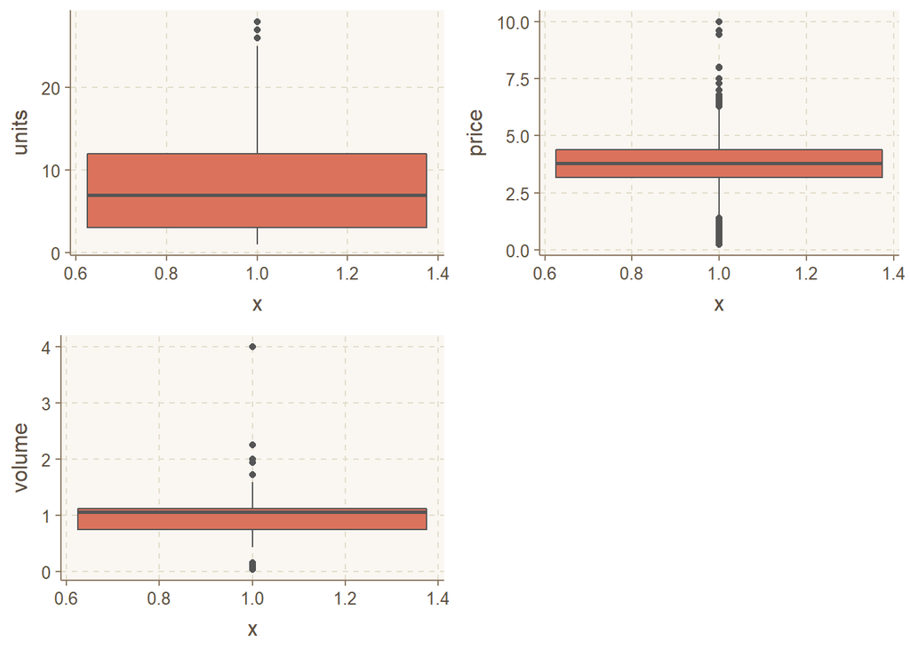

```r
# Code boxplots using grid.arrange so can see all quant variables together
grid.arrange(
  fd2 %>%
    ggplot(aes(x = 1, y = units)) +
      geom_boxplot(),
  fd2 %>%
    ggplot(aes(x = 1, y = price)) +
      geom_boxplot(),
  fd2 %>%
    ggplot(aes(x = 1, y = volume)) +
      geom_boxplot(),
  ncol = 2
)
```

## 3.3 Histograms

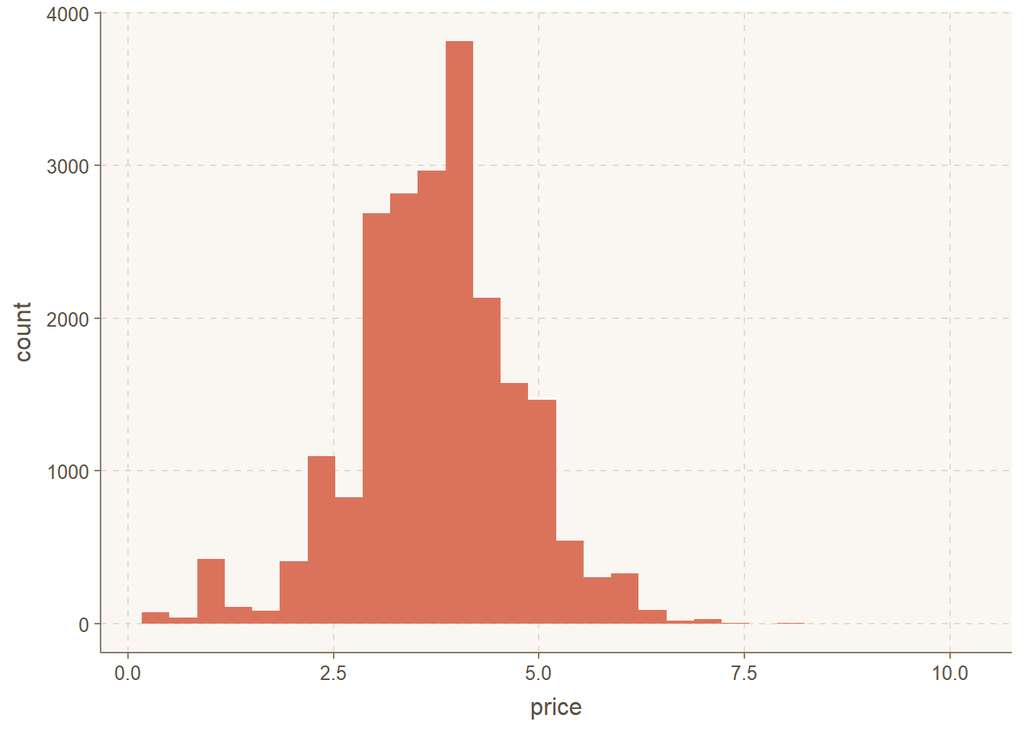

```r
grid.arrange(
  fd2 %>%
    ggplot(aes(price)) +
      geom_histogram(),
  ncol = 1
)
```

### 3.3.1 Comments

- Same data shown as with box-plots for price, just different side. Any price above 5 begins to peter out rapidly, same with below 2.5
- Are products sold very often in those ranges or is there a lack of information because of a lack of trying?

# 4 Multi-Variate Non-graphical EDA

## 4.1 Categorical Variables

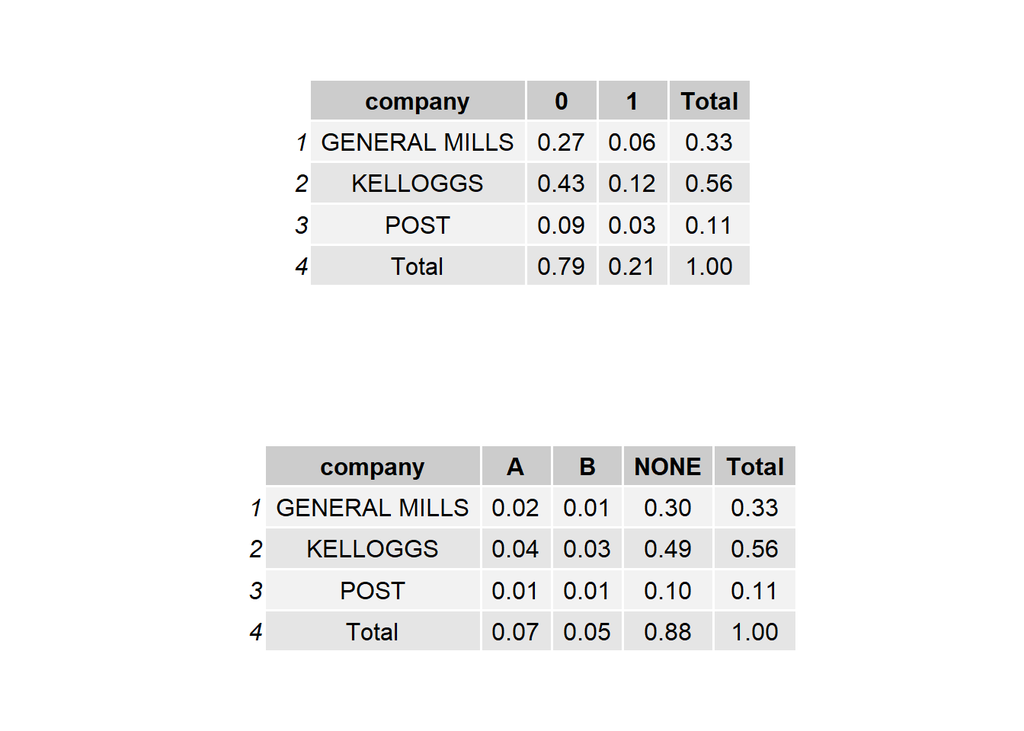

```r
#Comparing Company to Promotion and Advertisement

grid.arrange(
  tableGrob(
    fd2 %>%
      tabyl(company, promo) %>%
      adorn_totals(where = c("row","col")) %>%
      adorn_percentages(denominator = "all") %>%
      adorn_rounding(2)
  ),
  tableGrob(
    fd2 %>%
      tabyl(company, ad) %>%
      adorn_totals(where = c("row","col")) %>%
      adorn_percentages(denominator = "all") %>%
      adorn_rounding(2)
  ))
```

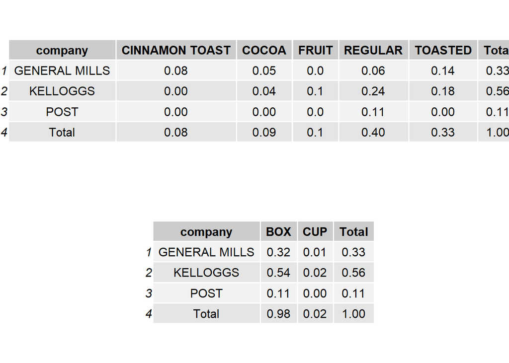

```r
#Comparing Company to Flavor and Packaging

grid.arrange(
  tableGrob(
    fd2 %>%
      tabyl(company, flavor) %>%
      adorn_totals(where = c("row","col")) %>%
      adorn_percentages(denominator = "all") %>%
      adorn_rounding(2)
  ),
 tableGrob(
    fd2 %>%
      tabyl(company, package) %>%
      adorn_totals(where = c("row","col")) %>%
      adorn_percentages(denominator = "all") %>%
      adorn_rounding(2)
  )
)
```

## 4.2 Quantitative Variables

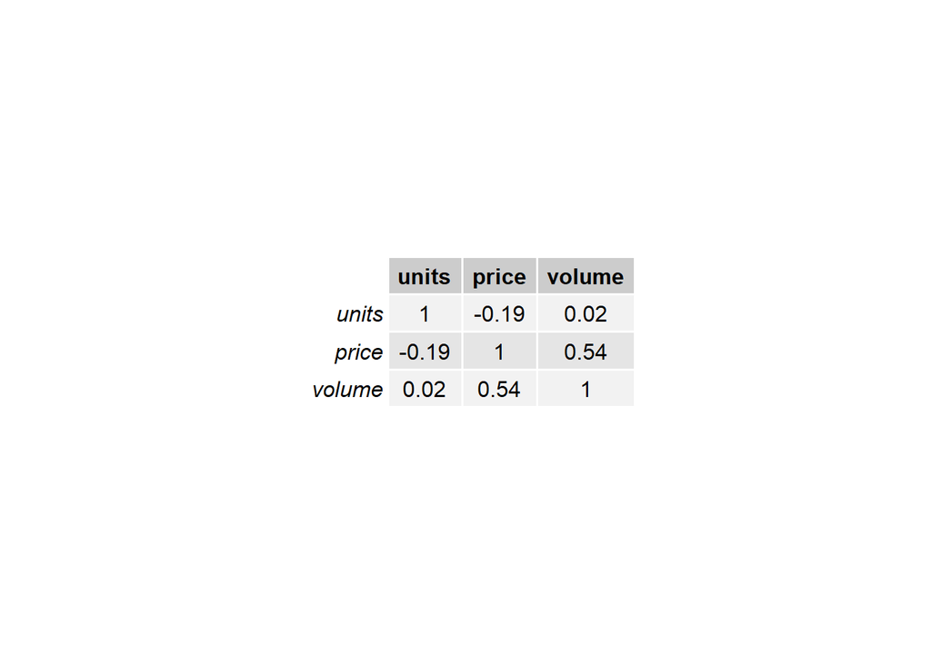

```r
#Breakdown of Quantitative Variables. Same style as above charts but using numeric variables
grid.arrange(
  tableGrob(
    fd2 %>%
      select_if(is.numeric)%>%
      cor() %>%
      round(2))
  )
```

### 4.2.1 Comments

- Higher volume associated with a higher price, which makes sense.
- Price and Units are negatively correlated, package deals?

# 5 Multi-variate graphical EDA

## 5.1 Bargraphs

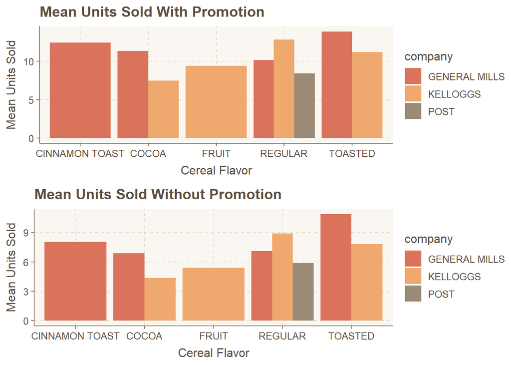

```r
#2 Bar graphs showing mean units sold with and without promotion, colored by company
grid.arrange(
fd2 %>%
  filter(promo == 1) %>% #with promotion
  group_by(flavor,company) %>% #what we will be using to help summarise
  summarise(mean_units = mean(units)) %>% #looking at mean units sold per flavor per company
  ggplot(aes(x = flavor,y = mean_units, fill = company)) +
  geom_col(position = "dodge") +
  labs(x = "Cereal Flavor", y = "Mean Units Sold", title = "Mean Units Sold With Promotion"),
fd2 %>%
  filter(promo == 0) %>% # without promotion
  group_by(flavor,company) %>% #what we will be using to help summarise
  summarise(mean_units = mean(units)) %>% #looking at mean units sold per flavor per company
  ggplot(aes(x = flavor,y = mean_units, fill = company)) +
  geom_col(position = "dodge") +
  labs(x = "Cereal Flavor", y = "Mean Units Sold", title = "Mean Units Sold Without Promotion"),

ncol = 1

)
```

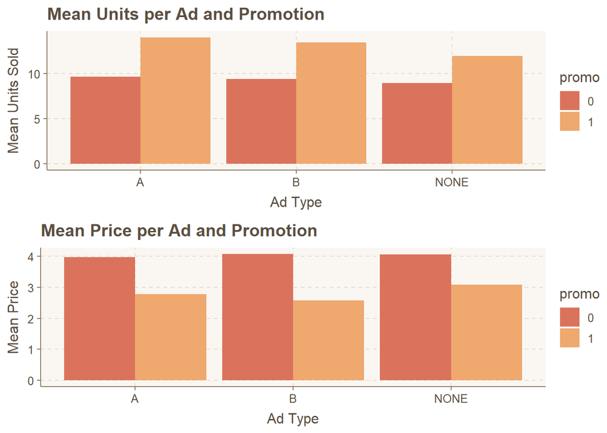

```r
# 2 bar graphs showing mean units and mean price for General Mills per Ad Type separated by whether there is a promotion or not
grid.arrange(
fd2 %>%
  filter(company == "GENERAL MILLS") %>% #filter to just general mills
  group_by(ad, promo,) %>%
  summarise(mean_units = mean(units)) %>%
  ggplot(aes(x = ad,y = mean_units, fill = promo)) +
  geom_col(position = "dodge") +
  labs(x = "Ad Type", y = "Mean Units Sold", title = "Mean Units per Ad and Promotion"),
fd2 %>%
  filter(company == "GENERAL MILLS") %>% #filter to just general mills
  group_by(ad, promo) %>%
  summarise(mean_price = mean(price)) %>%
  ggplot(aes(x = ad,y = mean_price, fill = promo)) +
  geom_col(position = "dodge") +
  labs(x = "Ad Type", y = "Mean Price", title = "Mean Price per Ad and Promotion"),
ncol = 1
)
```

### 5.1.1 Comments

- It seems like advertisement doesn’t have a huge impact on sales like promotions tend to have
- Kelloggs has the market for fruit cereal but we saw earlier that they make up a really tiny proportion
- Is there a specific area that we should not run ads or promotions on?
- Does the dip in price get made up in the increase in units sold?

## 5.2 Mean Units and Price by Brand

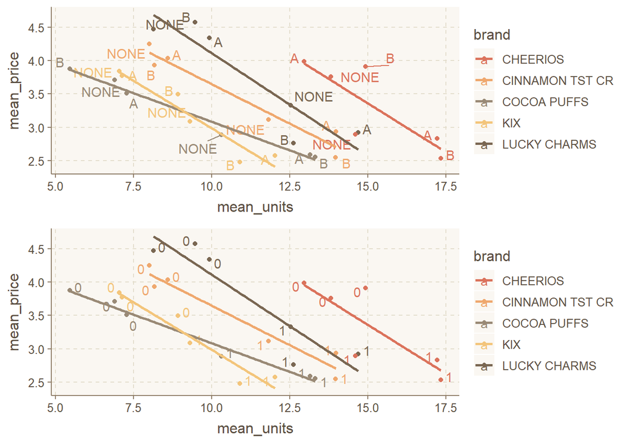

```r
#Taking a look at how mean units and mean price are affected by promo and ad. Color denoted brand.
#They are the same graph just labeled for ad and promo
grid.arrange(
  fd2 %>%
    filter(company == "GENERAL MILLS") %>% #filter to just general mills
    group_by(ad,promo,brand) %>% #use ad promo and brand to separate means
    summarise(mean_price = mean(price),mean_units = mean(units)) %>% #create mean units and price
    ggplot(aes(x = mean_units, y = mean_price, color = brand)) +
    geom_point() +
    geom_text_repel(aes(label = ad)) + #ggrepel to preven point/label overlap
    geom_smooth(method = "lm", se = FALSE),
  fd2 %>%
    filter(company == "GENERAL MILLS") %>% #filter to just general mills
    group_by(ad,promo,brand) %>% #use ad promo and brand to separate means
    summarise(mean_price = mean(price),mean_units = mean(units)) %>% #create mean units and price
    ggplot(aes(x = mean_units, y = mean_price, color = brand)) +
    geom_point() +
    geom_text_repel(aes(label = promo)) + #ggrepel to preven point/label overlap
    geom_smooth(method = "lm", se = FALSE),
  ncol = 1
  )
```

### 5.2.1 Comments

- Promotion has a far larger impact on mean price to units than ads do
  - This makes sense because an ad may not correlate with a decrease in cost
  - A promotion always has a 5% atleast discount so it makes sense that the value per unit is lesser
- I wonder if we could measure value for each promotion per brand

# 6 Detailed EDA

## 6.1 Questions we are going to try to answer

1.Which brands generate value from Promotion? 2.Which brands generate value from having Ads? 3.Which Ads are the most optimal for each brand? 4.Where is Kelloggs generating their value?

We are going to be using the variable Value as our score for the profitability of each possibility. Value is derived from mean_price * mean_units. This way we can account for both price decreases and unit sold increases from promotions. It will also help us determine if ads are valuable, as more units sold under advertisements is still valuable even if there isn’t a direct sale to the goods.

## 6.2 Which brands generate value from Promotion?

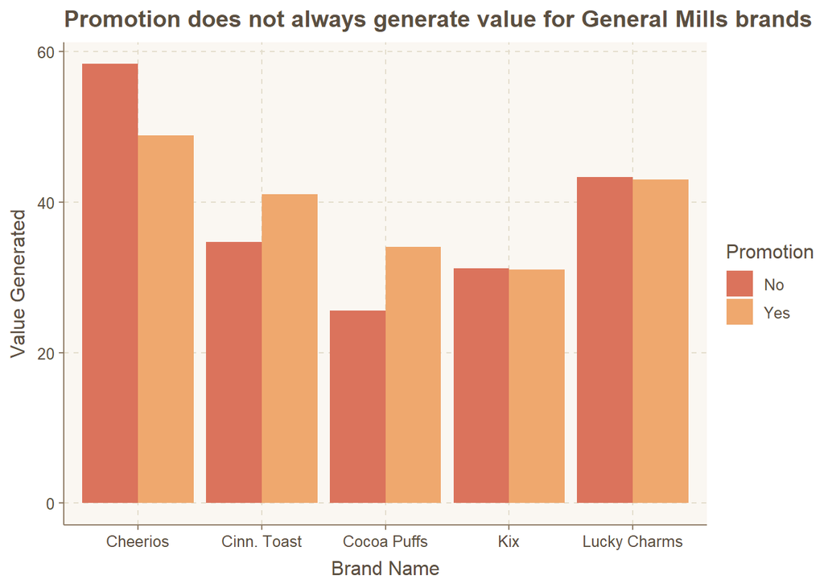

```r
#Save graph to PromoValue
PromoValue <- (
  fd2 %>%
    filter(company == "GENERAL MILLS") %>% #filter to just general mills

    mutate(promo = ifelse(promo == "0","No","Yes")) %>% #Change promo 0 into No and promo 1 into Yes

    group_by(ad,promo,brand) %>% #use ad promo and brand to separate means
    summarise(mean_price = mean(price),mean_units = mean(units), value = (mean_price*mean_units)) %>% #create mean units and price
    ggplot(aes(x = brand, y = value, fill = promo)) +
    geom_col(position = "dodge") +
    labs(x = "Brand Name", y = "Value Generated", title = "Promotion does not always generate value for General Mills brands", fill = "Promotion") +
  #Add labels to Brands for easier reading and prevention of overlapping
    scale_x_discrete(labels = c("CHEERIOS" = "Cheerios", "CINNAMON TST CR" = "Cinn. Toast", "COCOA PUFFS" = "Cocoa Puffs", "LUCKY CHARMS" = "Lucky Charms", "KIX" = "Kix"))
)


#Display Graph
PromoValue
```

### 6.2.1 Comments

- Cheerios, Kix, and Lucky Charms do not benefit from Promotions
  - This is found by using our Value equation to give us a “score” for each option
- Cinnamon Toast Crunch and Cocoa Puffs do benefit from promotions
  - This could be due to being more less adult-friendly than Cheerios and Kix
    - Although Lucky Charms is also a kid-friendly cereal more than adult-friendly

## 6.3 Which brands generate value from having Ads?

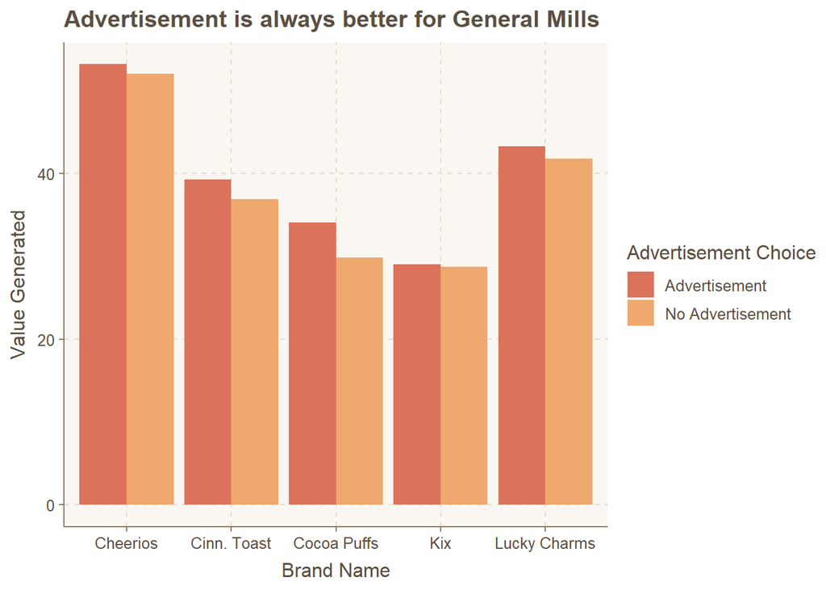

```r
#Read graph into AdValue
AdValue <- (
  fd2 %>%
    filter(company == "GENERAL MILLS") %>% #filter to just general mills

    #mutate ad to advert to reduce A and B into one, with NONE being No Advert
    mutate(advert = ifelse(ad == "A"|ad == "B", "Advertisement",
                         ifelse(ad == "NONE", "No Advertisement", "null"))) %>%

    group_by(advert,promo,brand) %>% #use ad promo and brand to separate means
    summarise(mean_price = mean(price),mean_units = mean(units), value = (mean_price*mean_units)) %>% #create mean units and price, value = mean units * mean price

    count(brand,value,advert) %>%
    ggplot(aes(x = brand, y = value, fill = advert)) +
    geom_col(position = "dodge") +
    labs(x = "Brand Name", y = "Value Generated", title = "Advertisement is always better for General Mills", fill = "Advertisement Choice") +
  #Add labels to Brands for easier reading and prevention of overlapping
    scale_x_discrete(labels = c("CHEERIOS" = "Cheerios", "CINNAMON TST CR" = "Cinn. Toast", "COCOA PUFFS" = "Cocoa Puffs", "LUCKY CHARMS" = "Lucky Charms", "KIX" = "Kix"))
)
#Display Graph
AdValue
```

### 6.3.1 Comments

- Possible that one advertisement option is propping up the other
  - But if we are looking for a net effect, its clear that Advertisement is better
- Kix benefits the least, but still benefits from Advertisement
- Cocoa Puffs gets the most value out of Advertisement

## 6.4 Which Ads are the most optimal for each brand?

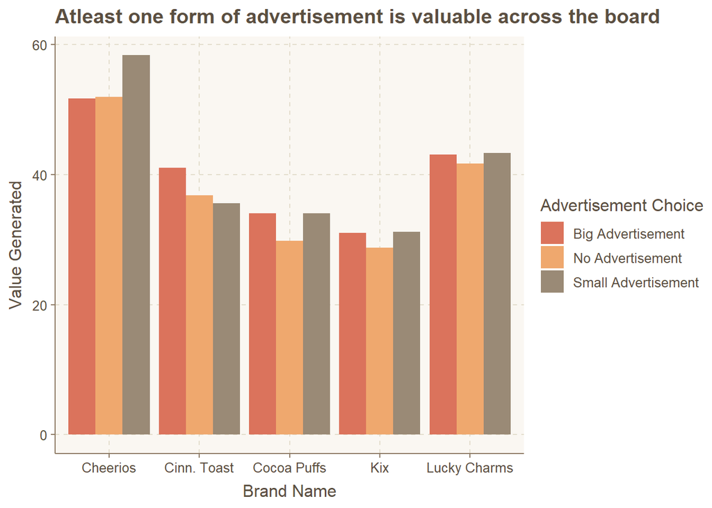

```r
#Read graph into BrandValue
BrandValue <- (
  fd2 %>%
    filter(company == "GENERAL MILLS") %>% #filter to just general mills

    #mutate ad to say big ad for A, small ad for B, or No ad
    mutate(ad = ifelse(ad == "A", "Big Advertisement",
                         ifelse(ad == "B","Small Advertisement", "No Advertisement"))) %>%


    group_by(ad,promo,brand) %>% #use ad promo and brand to separate means
    summarise(mean_price = mean(price),mean_units = mean(units), value = (mean_price*mean_units)) %>% #create mean units and price, create value variable
    ggplot(aes(x = brand, y = value, fill = ad)) +
    geom_col(position = "dodge") +
    labs(x = "Brand Name", y = "Value Generated", title = "Atleast one form of advertisement is valuable across the board", fill = "Advertisement Choice") +
  #Add labels to Brands for easier reading and prevention of overlapping
    scale_x_discrete(labels = c("CHEERIOS" = "Cheerios", "CINNAMON TST CR" = "Cinn. Toast", "COCOA PUFFS" = "Cocoa Puffs", "LUCKY CHARMS" = "Lucky Charms", "KIX" = "Kix"))
)
#Display Graph
BrandValue
```

### 6.4.1 Comments

- In every case, there is a form of advertisement that is better than no advertisement
- Cheerios benefits from small advertisement, but loses value with big advertisements
- Cinnamon Toast Crunch benefits from big advertisements, but loses value with small advertisements
- Lucky Charms has an equal benefit from Small and Big Advertisements
  - Same with Kix and Cocoa Puffs

## 6.5 What Sales and Promotions is Kelloggs doing that is successful?

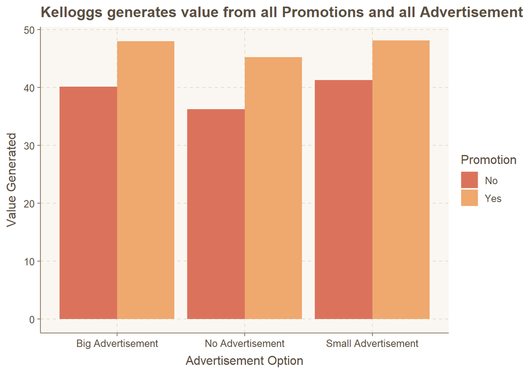

```r
#Read Graph into KellogsValue
KelloggsValue <- (
  fd2 %>%
    filter(company == "KELLOGGS") %>% #filter to just general mills

    mutate(promo = ifelse(promo == "0","No","Yes")) %>% #Change promo 0 into No and promo 1 into Yes
    #mutate ad to say big ad for A, small ad for B, or No ad
    mutate(ad = ifelse(ad == "A", "Big Advertisement",
                         ifelse(ad == "B","Small Advertisement", "No Advertisement"))) %>%

    group_by(ad,promo,brand) %>% #use ad promo and brand to separate means
    summarise(mean_price = mean(price),mean_units = mean(units), value = (mean_price*mean_units)) %>% #create mean units and price, create value variable
    ggplot(aes(x = ad, y = value, fill = promo)) +
    geom_col(position = "dodge")) +
    labs(x = "Advertisement Option", y = "Value Generated", title = "Kelloggs generates value from all Promotions and all Advertisements", fill = "Promotion")
#Display Graph
KelloggsValue
```

### 6.5.1 Comments

- Kelloggs benefits from all promotion in conjunction with every option

# 7 Statistical EDA

## 7.1 Promotions Improve Units Sold

### 7.1.1 Establish Hypothesis

Null: Promotions do not increase the amount of units sold Alternative: Promotions do increase the amount of units sold Level of Confidence: 0.05

### 7.1.2 Test Hypothesis

```r
t.test(fd2$units[fd2$promo == "1"],fd2$units[fd2$promo == "0"])
```

```
##
##  Welch Two Sample t-test
##
## data:  fd2$units[fd2$promo == "1"] and fd2$units[fd2$promo == "0"]
## t = 27.59, df = 6398.8, p-value < 2.2e-16
## alternative hypothesis: true difference in means is not equal to 0
## 95 percent confidence interval:
##  3.070437 3.540125
## sample estimates:
## mean of x mean of y
## 11.196700  7.891419
```

## 7.2 Advertisements Improve Units Sold

### 7.2.1 Establish Hypothesis

Null: Advertisements do not increase the amount of units sold Alternative: Advertisements do increase the amount of units sold Level of Confidence: 0.05

### 7.2.2 Test Hypothesis

```r
t.test(fd2$units[fd2$ad == "A" | fd2$ad == "B"],fd2$units[fd2$ad == "NONE"])
```

```
##
##  Welch Two Sample t-test
##
## data:  fd2$units[fd2$ad == "A" | fd2$ad == "B"] and fd2$units[fd2$ad == "NONE"]
## t = 17.093, df = 3032.3, p-value < 2.2e-16
## alternative hypothesis: true difference in means is not equal to 0
## 95 percent confidence interval:
##  2.372284 2.987070
## sample estimates:
## mean of x mean of y
## 10.949940  8.270263
```

# 8 Main EDA Comments

- While Promotion is not always in General Mills’ best interest to generate value, it is always in Kelloggs’ interest
- General Mills brands all benefit from at least one form of advertisement over no advertisement

# 9 Save graphs for use in memo

```r
# Can load into other documents like any other .png file
ggsave("PromoValue.png", plot = PromoValue, scale = 1.3)
ggsave("BrandValue.png", plot = BrandValue, scale = 1.3)
```